# Statistical inference with the GSS data

## Setup

PROJECT AUTHOR : SANDIPAN MAJHI.

### Load packages

```r
library(ggplot2)
library(dplyr)
library(statsr)
```

### Load data

Make sure your data and R Markdown files are in the same directory. When loaded your data file will be called `gss`. Delete this note when before you submit your work.

```r
load("gss.Rdata")
```

## Part 1: Data

The General Social Survey (GSS) is a sociological survey created and regularly collected since 1972 by the National Opinion Research Center at the University of Chicago. It is funded by the National Science Foundation. The GSS collects information and keeps a historical record of the concerns, experiences, attitudes, and practices of residents of the United States.

The GSS sample is drawn using an area probability design that randomly selects respondents in households across the United States to take part in the survey. Respondents that become part of the GSS sample are from a mix of urban, suburban, and rural geographic areas. Participation in the study is strictly voluntary.

As the data is randomly sampled it could be assumed that the responses are independent of one another. There is very less chance of bias.So the data can be generalized to the population.

As per the inference statistics is concerned there is no way hypothesis tests confirm causality.

## Part 2: Research question

Research Question 1 :

We want to check whether there is enough evidence to suggest that adhering to one’s religions shape one’s idea whether homosexual relationships are wrong or not.We will be then doing a hypothesis test to answer our question.

We want to check this question as to check whether pro-homosexual relation based government policies can upset a majority of religious populations or not. It is important for any political party to understand the circumstances. If infact the country is driven by religiously biased constitution, the political party might lose the such election in such kind of government policies.

## Part 3: Exploratory data analysis

NOTE: Insert code chunks as needed by clicking on the “Insert a new code chunk” button (green button with orange arrow) above. Make sure that your code is visible in the project you submit. Delete this note when before you submit your work.

Research Question 1:

The data seems to be right skewed.

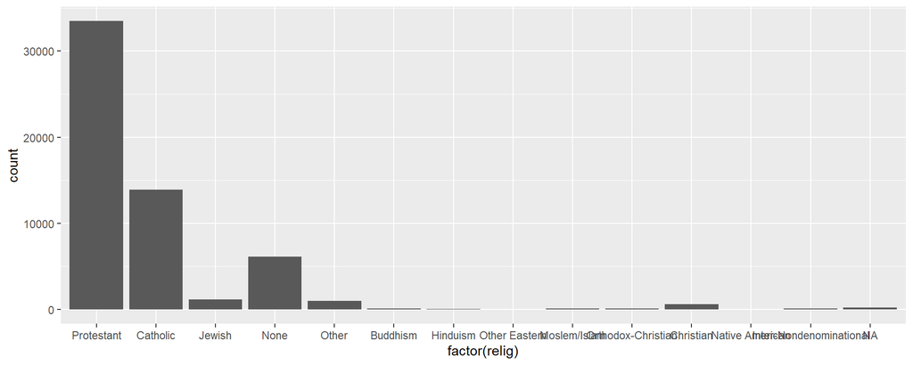

```r
ggplot(data = gss, aes(x = factor(relig))) + geom_histogram(stat = "count")
```

```r
gss <- gss %>% filter(!is.na(relig)) %>%
  mutate(is_ath = if_else(relig == "None", "Yes", "No"))
```

Now we will check if the data satisfy the nearly normality conditions for proportions. That is at least 10 successes and 10 failures and the data being independent within groups and between groups. To answer that we will at first make a new table, named as, `hom_relig`. In this table we will be recording if the respondent is atheist or not in `is_ath` and the values in the variable `homosex` in a new variable `homo`.

```r
hom_relig <- gss %>%
  filter(!is.na(is_ath), !is.na(homosex)) %>%
  select(is_ath = is_ath, homo = homosex)
```

After this we will do some changes in the response in the `homo` variable. We will segregate them in a binary response. We introduce a new variable `liberal` which states if the response is if response to homosexual relations as `Sometimes Wrong` or `Not Wrong At All`, we mark `liberal` as `Yes` and else `No`. After that let us check the distribution of the variable `liberal`.

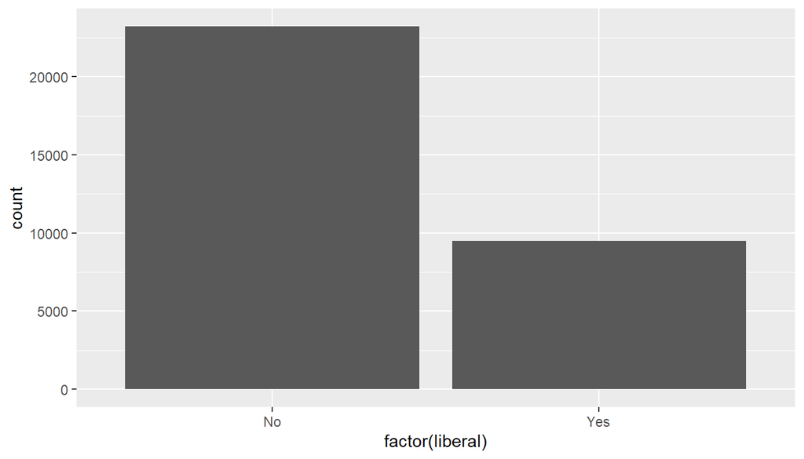

```r
hom_relig <- hom_relig %>%
  mutate(liberal = if_else(homo == "Sometimes Wrong" | homo == "Not Wrong At All", "Yes", "No"))

ggplot(data = hom_relig, aes(x = factor(liberal))) + geom_histogram(stat = "count")
```

Let’s do some EDA on this table `hom_relig`. We will check the proportion of the respondents who are `liberal`.

```r
hom_relig %>%
  group_by(liberal) %>%
  summarise(prop = n()/count(hom_relig))
```

```
## # A tibble: 2 x 2
##   liberal prop$n
##   <chr>    <dbl>
## 1 No       0.709
## 2 Yes      0.291
```

Let us also check the data where response from `liberal` and `is_ath` are grouped together. We will have a comprehensive idea of the problem at hand. We will be checking the proportions.

```r
hom_relig %>%
  group_by(liberal, is_ath) %>%
  summarise(count = n()/count(hom_relig))
```

```
## # A tibble: 4 x 3
## # Groups:   liberal [2]
##   liberal is_ath count$n
##   <chr>   <chr>    <dbl>
## 1 No      No      0.670
## 2 No      Yes     0.0393
## 3 Yes     No      0.227
## 4 Yes     Yes     0.0631
```

So we see that there are numerous people in the set who are not liberal about homosexual relationships and also not atheist.

After this we move on to the inference part.

## Part 4: Inference

NOTE: Insert code chunks as needed by clicking on the “Insert a new code chunk” button (green button with orange arrow) above. Make sure that your code is visible in the project you submit. Delete this note when before you submit your work.

Research Question 1 :

Main idea : Religious people are not liberal about homosexual relationships. `liberal` variable is the response variable and `is_ath` the explanatory variable.

First let us state the hypothesis. We will be comparing two proportions of atheists and the religious people.

Null Hypothesis : There is nothing going on, the proportions of atheists and the proportions of the religious people being not liberal is same.

Alternative hypothesis : There is something going on the proportion of religious people do tend to be less liberal than the proportion of the people who are atheists.

Conditions Check up :

1. Independence : The data is randomly selected so we can be sure that the participant’s response is independent of the other.The number of population is also less than 10% of the total population.
2. Success Failure condition : Our response variable is `liberal` and the explanatory variable is `is_ath`. Let us check the two way table.

```r
hom_relig %>%
  group_by(liberal, is_ath) %>%
  summarise(count = n())
```

```
## # A tibble: 4 x 3
## # Groups:   liberal [2]
##   liberal is_ath count
##   <chr>   <chr>  <int>
## 1 No      No     21919
## 2 No      Yes     1284
## 3 Yes     No      7439
## 4 Yes     Yes     2063
```

There are atleast 10 success and 10 failures. So this condition is also met.

Methodology : We will be comparing the two proportions here. The two proportions being proportions of the respondents who are religious and another who are atheists. The response variable’s success is `No`. We will be looking at whether proportions of religious people who are `not` liberal about homosexual relations are greater. So we will looking at the upper tail of the distribution. We don’t need simulation here, we will be checking the theoretical method only.

Inference Test :

```r
inference(y=liberal, x = factor(is_ath), data = hom_relig, statistic = "proportion", type = "ht", method = "theoretical", null = 0, alternative = "greater", success = "No")
```

```
## Response variable: categorical (2 levels, success: No)
## Explanatory variable: categorical (2 levels)
## n_No = 29358, p_hat_No = 0.7466
## n_Yes = 3347, p_hat_Yes = 0.3836
## H0: p_No =  p_Yes
## HA: p_No > p_Yes
## z = 43.8234
## p_value = < 0.0001
```

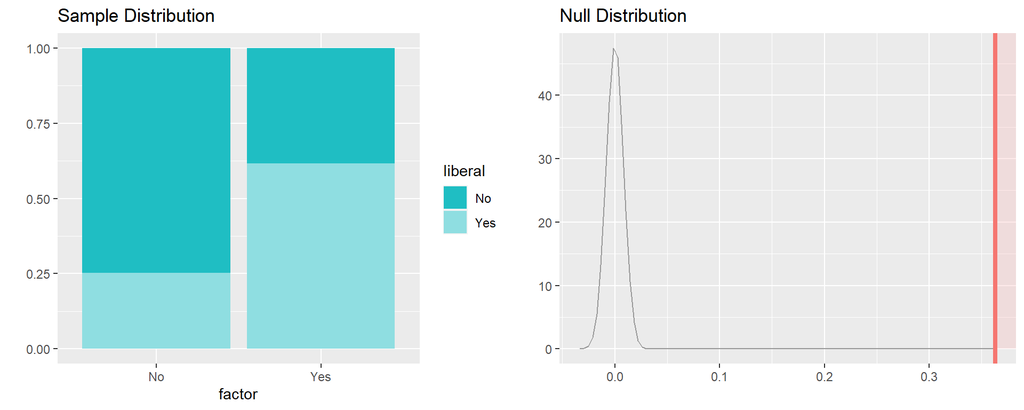

Let us also get the 95% confidence intervals.

```r
inference(y=liberal, x = factor(is_ath), data = hom_relig, statistic = "proportion", type = "ci", method = "theoretical", null = 0, alternative = "greater", success = "No")
```

```
## Response variable: categorical (2 levels, success: No)
## Explanatory variable: categorical (2 levels)
## n_No = 29358, p_hat_No = 0.7466
## n_Yes = 3347, p_hat_Yes = 0.3836
## 95% CI (No - Yes): (0.3458 , 0.3802)
```

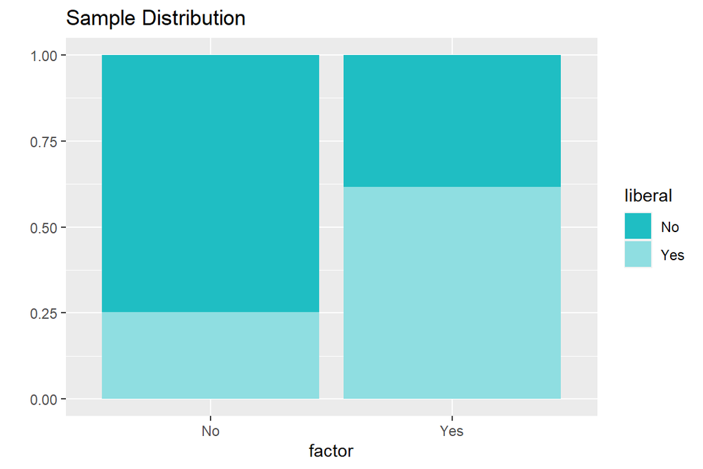

Interpretation :

We can see that the value 0 is not present in the confidence interval. In the hypothesis test as expected we got p-value less than 0.0001. So we reject the null hypothesis that there is nothing going on or being religious has nothing to do with being liberal. So we conclude that there is enough evidence that religious people do tend to less liberal when judging homosexual relationships. We have included 95% confidence interval here in our project because we are checking differences of proportions.